# ES 207 Homework 6 - Modeling Part 1

# Overview

Ordinary Least Squares (OLS), commonly referred to as linear regression, is a very important tool for the statistical analysis of environmental data. It is used to describe the covariation between some variable of interest and one or more other variables.

Multiple linear regression (MLR) is the extension of simple linear regression (SLR) to the case of multiple explanatory variables. The goal of this relationship is to explain as much as possible of the variation observed in the response ($y$) variable, leaving as little variation as possible to unexplained “noise”.

# Objectives

- Create, apply and evaluate linear regression models
- Explain the assumptions of linear regression models, and perform model diagnostic analysis
- Use the split-apply-combine approach in R with the tidyverse to build many models at once
- Conduct multiple linear regression and paralelle regression, including applying and evaluating model performance
- Explain the common pitfalls of MLR such as multi-collinearity and relying on $R^2$

# Making publication quality graphics

In this case, we want to practice making some publication quality graphics. Please read [this] (https://journals.plos.org/ploscompbiol/article?id=10.1371/journal.pcbi.1003833) article by Rougier et al. (2014) for some nice tips on making publication quality graphics.

Some key aspects of good publication quality figures are:

1. Good captions
- Describe what is graphed
- Include important experimental details
- Identify multiple curves (if present) or traces
- Match the graphic
2. Good readability
- Good resolution
- Clear, concise, and complete
- Font is legible
- Colors enhance graphic not detract
- All parts of figure are identified or explained
- Figure is proofed carefully
3. Label axes clearly
- Include a y-axis
- Use the *correct* unit
- Identify the variable
- Use the same format
- Avoid only symbols with less common names
4. Include a scale or scale bar (if appropriate)
- select scale wisely
5. Check for accuracy (proof your work)

```r
library(tidyverse)
```

```r
tufte_summary <- tibble(
  Good = c("Terms are spelled out", "Text runs left to right", "Data are clarified with small notes", "Legends vs. labels - decide which one is appropriate", "Graohics attract viewer", "Color choices -blue is good", "Font type is clear, precise, modest", "Upper & lower case, with serifs", "Graphics should tend toward horizontal - greater in length than height"),
  Bad = c("Excessive abbreviations to decode", "Text in vertical or multiple directions", "Graphic requires repeated references to scattered text", "Repeated back and forth between legend and graphic required", "Graphic is filled with chartjuunk", "Dark letters on dark contrast", "Uses red and green only", "Type is dense, heavy, overbearing", "All upper case, sans serif")
)
knitr::kable(tufte_summary, caption = "Attributes of good and bad graphics")
```

Attributes of good and bad graphics

| Good | Bad |
| --- | --- |
| Terms are spelled out | Excessive abbreviations to decode |
| Text runs left to right | Text in vertical or multiple directions |
| Data are clarified with small notes | Graphic requires repeated references to scattered text |
| Legends vs. labels - decide which one is appropriate | Repeated back and forth between legend and graphic required |
| Graohics attract viewer | Graphic is filled with chartjuunk |
| Color choices -blue is good | Dark letters on dark contrast |
| Font type is clear, precise, modest | Uses red and green only |
| Upper & lower case, with serifs | Type is dense, heavy, overbearing |
| Graphics should tend toward horizontal - greater in length than height | All upper case, sans serif |

> 1. Complete Qian text Chapter 5 Question 4a. Make a publication quality graph of the scatter plot and the residual plot. Answer the question as directed.

> 2. Complete Qian text Chapter 5 Question 4b and 4c.

# Compare predictions

We can use the `modelr` package and the very cool function `add_predictions()` or `spread_predictions()` to get our modeled predictions of mortality into the original tibble. That will enable us to compare different model predictions to the original observations.

First, I will create two models. The first uses `nox` to predict `mort`. The second uses `nox` and `hc` and `so2` to predict `mort`.

**Note** - I am not transofrming any data here. This is probably not a great idea - you’ll see some crappy model results below!

*Always* make sure to investigate and apply appropriate transformations and always document your work and reasining behind each transofmration in your notebook.

```r
dat <- read_csv("readings/eesR-master/R/Data/pollution.csv")
mod1 <- lm(mort~nox, data = dat)
mod2 <- lm(mort~nox + hc + so2, dat = dat)
```

```r
library(modelr)
?modelr::add_predictions

dat <- dat %>%
  spread_predictions(predict_mort_mod1 = mod1, predict_mort_mod2 = mod2)
dat
```

| prec | jant | jult | ovr65 | popn | educ | hous | dens | nonw | wwdrk | poor | hc | nox | so2 | humid | mort | predict_mort_mod1 | predict_mort_mod2 |
| --- | --- | --- | --- | --- | --- | --- | --- | --- | --- | --- | --- | --- | --- | --- | --- | --- | --- |
| 36 | 27 | 71 | 8.1 | 3.34 | 11.4 | 81.5 | 3243 | 8.8 | 42.6 | 11.7 | 21 | 15 | 59 | 59 | 921.870 | 941.1532 | 946.1427 |
| 35 | 23 | 72 | 11.1 | 3.14 | 11.0 | 78.8 | 4281 | 3.5 | 50.7 | 14.4 | 8 | 10 | 39 | 57 | 997.875 | 941.6726 | 948.4316 |
| 44 | 29 | 74 | 10.4 | 3.21 | 9.8 | 81.6 | 4260 | 0.8 | 39.4 | 12.4 | 6 | 6 | 33 | 54 | 962.354 | 942.0882 | 938.7151 |
| 47 | 45 | 79 | 6.5 | 3.41 | 11.1 | 77.5 | 3125 | 27.1 | 50.2 | 20.6 | 18 | 8 | 24 | 56 | 982.291 | 941.8804 | 923.4179 |
| 43 | 35 | 77 | 7.6 | 3.44 | 9.6 | 84.6 | 6441 | 24.4 | 43.7 | 14.3 | 43 | 38 | 206 | 55 | 1071.289 | 938.7638 | 1007.6358 |
| 53 | 45 | 80 | 7.7 | 3.45 | 10.2 | 66.8 | 3325 | 38.5 | 43.1 | 25.5 | 30 | 32 | 72 | 54 | 1030.380 | 939.3871 | 984.1240 |
| 43 | 30 | 74 | 10.9 | 3.23 | 12.1 | 83.9 | 4679 | 3.5 | 49.2 | 11.3 | 21 | 32 | 62 | 56 | 934.700 | 939.3871 | 996.6397 |
| 45 | 30 | 73 | 9.3 | 3.29 | 10.6 | 86.0 | 2140 | 5.3 | 40.4 | 10.5 | 6 | 4 | 4 | 56 | 899.529 | 942.2959 | 927.0283 |
| 36 | 24 | 70 | 9.0 | 3.31 | 10.5 | 83.2 | 6582 | 8.1 | 42.5 | 12.6 | 18 | 12 | 37 | 61 | 1001.902 | 941.4648 | 937.7655 |
| 36 | 27 | 72 | 9.5 | 3.36 | 10.7 | 79.3 | 4213 | 6.7 | 41.0 | 13.2 | 12 | 7 | 20 | 59 | 912.347 | 941.9843 | 929.3616 |

[output cut: 50 more lines]

```r
# not run - but check these out - pretty cool!
#dat.g <- dat %>%
#  gather_predictions(mod1, mod2)
#dat.g
#dat.r <- dat %>%
#  spread_residuals(mod1, mod2)
#dat.r
```

My result is a tibble with new columns for the predicted mortality based on the two models.

Let’s visualize the differences in predictions.

To do this, we need to wrangle our data again

```r
predictions <- dat %>%
  gather(key = model_num, value = pred_mortality, "predict_mort_mod1", "predict_mort_mod2") %>%
  select("mort", "model_num", "pred_mortality")
predictions$model_num <- as.factor(predictions$model_num)
predictions
```

| mort | model_num | pred_mortality |
| --- | --- | --- |
| 921.870 | predict_mort_mod1 | 941.1532 |
| 997.875 | predict_mort_mod1 | 941.6726 |
| 962.354 | predict_mort_mod1 | 942.0882 |
| 982.291 | predict_mort_mod1 | 941.8804 |
| 1071.289 | predict_mort_mod1 | 938.7638 |
| 1030.380 | predict_mort_mod1 | 939.3871 |
| 934.700 | predict_mort_mod1 | 939.3871 |
| 899.529 | predict_mort_mod1 | 942.2959 |
| 1001.902 | predict_mort_mod1 | 941.4648 |
| 912.347 | predict_mort_mod1 | 941.9843 |

[output cut: 110 more lines]

Notice that I now have twice as many rows as before. That is because I am doubling the observed mortality to have an entry for each model.

Now we can use ggplot effectively

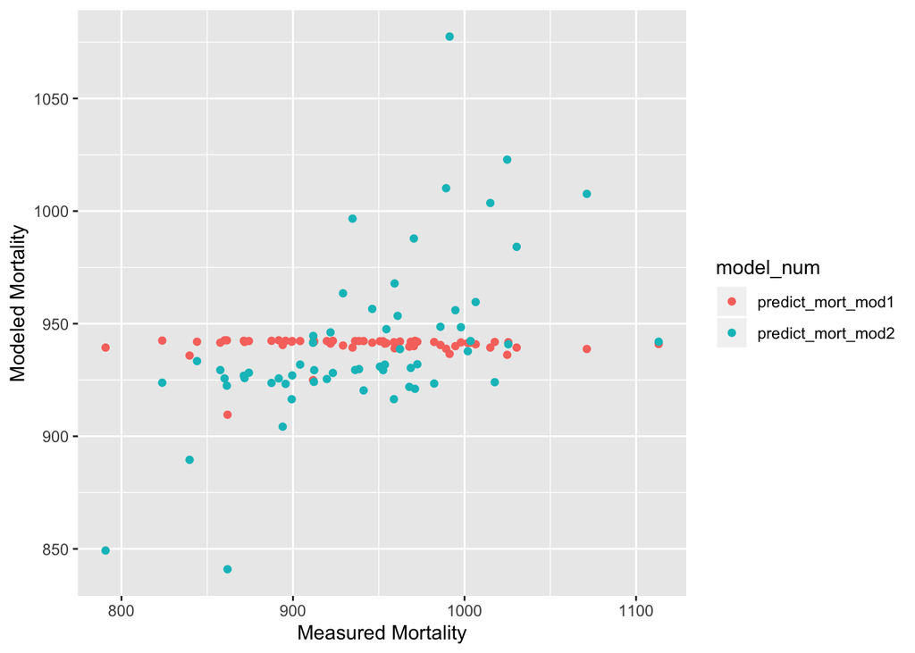

```r
ggplot(predictions, aes(x = mort, y = pred_mortality, color = model_num)) +
  geom_point() +
  xlab("Measured Mortality") +
  ylab("Modeled Mortality")
```

Next, let’s using some common model assessment statistics:

**Root mean square error (RMSE)**, and **mean absolute error (MAE)** are both commonly used to evaluate models by summarizing the differences between the observed and the predicted values.

- **MAE** gives equal weight to all errors. $MAE = \overline{abs(obs-modeled)}$ or $MAE = \frac{\sum_{i=1}^N \mid(y_{i}-x_{i})\mid}{N}$
- **RMSE** gives extra weight to large errors.  
  $RMSE = \sqrt{\overline{(pred-obs)^2}}$ or $RMSE = \sqrt{\sum_{i=1}^{N}(pred_i - obs_i)^2/N}$

Both values are given in units of the observation.

**Percent bias (Pbias)** measures the average tendency of the retrieved values to be larger or smaller than their observed ones.

- The optimal value is 0.0, with low-magnitude values indicating an accurate retrieval.
- Positive values indicate overestimation bias, while negative values indicate underestimation bias.

$pbias = 100*(\frac{\sum_{i=1}^N(pred_{i}-obs_{i})}{\sum_{i=1}^N(obs_{i})}$

> 4. Write a function that calculates each of the above statistics, and returns a tibble that where the column heading is the model name, and each row is a statistic. Name your function something logical so you can use it for future work (e.g., model_assess.R). Push your .R script to a new GitHub repo called es207_hw6.

> 5. Complete Qian text Chapter 5 Question 5d.

> 6. Complete Qian text Chapter 5 Question 5e. Include all relevant model diagnostics, including summary statistics and residual plots. Also make sure to include applying the function from question 4 to compare and assess your results.

> 7. Complete Qian text Chapter 5 Question 5f.

# Many Models

## Doing a Bunch of Regressions (or any other stats) at Once: The Split-Apply-Combine Approach

Often, we need to perform many regressions across multiple different treatments. The split-apply-combine approach is a very effective way to apply the same function on many different datasets based on a factor, or number of factors.

In this example, we are going to evaluate how orthophosphate $PO_{4}$ covaries with soluble reactive P (SRP), or *plant available* P in the soil at a study farm in Ohio.

SRP consists not only of $PO_{4}$, but also some acid-labile phosphorous compounds. Some researchers have found that SRP analysis can overestimate $PO_{4}$ concentrations, but others show the two measures are comparable, while others show the the reliability of SRP to estimate $PO_{4}$ varies temporally and spatially.

Our goal is to determine how much of the variation in $PO_{4}$ is explained by the SRP.

*Note* these data and example problem are courtesy of Dr. Emily Duncan (USDA NRCS)

The data are organized by site. Each row of data represents the event mean concentration of SRP for the 25th, 50th, 75, 95 percentile and max concentration events at that outlet (surface or tile). The soil test phosphorus columns contain the log transformed Mehlich 3 values for 3 different depths, one value per field.

The objective is to regress the [PO4] Column (by percentile and source—surface runoff or tile drainage) against the corresponding log transformed soil test P for each depth (0-2 inch, 0-4 in, 0-8 in).

### Read and Wrangle Data

First, lets read in our data. We want to use the tidyverse read_excel() which is supes fast and smart about parsing data.

Also, in the future, never save your data in excel spreadsheets. Always save as `.csv`. Excel spreadsheets do hinky encoding things to strings and dates and can corrupt your data. common separated values are much safer.

But sometimes we get data in Excel format, and we have to live with it. So, here we go…

```r
library(tidyverse)
library(readxl)
psoil <- read_excel("labs/Event_data_log.xlsx")
psoil
```

| site | log_PO4 | percentile | log_0_2 | log_0_4 | log_0_8 | source |
| --- | --- | --- | --- | --- | --- | --- |
| BE1 | -0.74052558 | 25 | 1.385714 | 1.252610 | 1.293528 | surface |
| BE1 | -0.51999306 | 50 | 1.385714 | 1.252610 | 1.293528 | surface |
| BE1 | -0.31403446 | 75 | 1.385714 | 1.252610 | 1.293528 | surface |
| BE1 | -0.25975577 | 95 | 1.385714 | 1.252610 | 1.293528 | surface |
| BE1 | -0.23284413 | max | 1.385714 | 1.252610 | 1.293528 | surface |
| BE2 | -1.41453927 | 25 | 1.385714 | 1.252610 | 1.293528 | tile |
| BE2 | -1.22914799 | 50 | 1.385714 | 1.252610 | 1.293528 | tile |
| BE2 | -1.00000000 | 75 | 1.385714 | 1.252610 | 1.293528 | tile |
| BE2 | -0.61672335 | 95 | 1.385714 | 1.252610 | 1.293528 | tile |
| BE2 | -0.12959609 | max | 1.385714 | 1.252610 | 1.293528 | tile |

[output cut: 295 more lines]

Hm. Ok. Our data are not tidy yet. We need to do some wrangling, so that we have two columns, one that is your measurement, and one that is your depth (since this is your categorical variable that you want to define your groups by).

`spread()` and `gather()` are your friends in this case.

```r
psoil.g <- gather(psoil, key = "depth", value = "soiltest", log_0_2, log_0_4, log_0_8)
psoil.g
```

| site | log_PO4 | percentile | source | depth | soiltest |
| --- | --- | --- | --- | --- | --- |
| BE1 | -0.74052558 | 25 | surface | log_0_2 | 1.385714 |
| BE1 | -0.51999306 | 50 | surface | log_0_2 | 1.385714 |
| BE1 | -0.31403446 | 75 | surface | log_0_2 | 1.385714 |
| BE1 | -0.25975577 | 95 | surface | log_0_2 | 1.385714 |
| BE1 | -0.23284413 | max | surface | log_0_2 | 1.385714 |
| BE2 | -1.41453927 | 25 | tile | log_0_2 | 1.385714 |
| BE2 | -1.22914799 | 50 | tile | log_0_2 | 1.385714 |
| BE2 | -1.00000000 | 75 | tile | log_0_2 | 1.385714 |
| BE2 | -0.61672335 | 95 | tile | log_0_2 | 1.385714 |
| BE2 | -0.12959609 | max | tile | log_0_2 | 1.385714 |

[output cut: 905 more lines]

> 8. Re-write the code as above, but use the piping function preferred by the tidyverse. Prove you get the same output.

Now, we need to get just the depth values (the numbers) out of the character string in our new “depth” column.

```r
psoil.g$depth <- substr(psoil.g$depth, start = 7, stop = 7)
psoil.g
```

| site | log_PO4 | percentile | source | depth | soiltest |
| --- | --- | --- | --- | --- | --- |
| BE1 | -0.74052558 | 25 | surface | 2 | 1.385714 |
| BE1 | -0.51999306 | 50 | surface | 2 | 1.385714 |
| BE1 | -0.31403446 | 75 | surface | 2 | 1.385714 |
| BE1 | -0.25975577 | 95 | surface | 2 | 1.385714 |
| BE1 | -0.23284413 | max | surface | 2 | 1.385714 |
| BE2 | -1.41453927 | 25 | tile | 2 | 1.385714 |
| BE2 | -1.22914799 | 50 | tile | 2 | 1.385714 |
| BE2 | -1.00000000 | 75 | tile | 2 | 1.385714 |
| BE2 | -0.61672335 | 95 | tile | 2 | 1.385714 |
| BE2 | -0.12959609 | max | tile | 2 | 1.385714 |

[output cut: 905 more lines]

### Visualize Data

ggplot FTW!

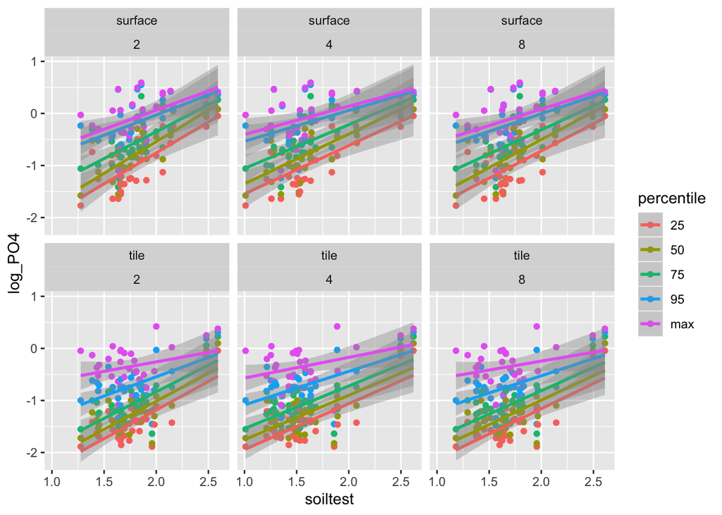

```r
ggplot(psoil.g, aes(x = soiltest, y = log_PO4, color = percentile)) + geom_point() + geom_smooth(method = "lm") + facet_wrap(source~depth)
```

### Creating list-columns (the Split part of split-apply-combine)

Now, we are going to create a list column. This is going to group the data by depth, percentile, and by tile/surface

```r
psoil.nested <- psoil.g %>%
  group_by(depth, source, percentile) %>%
  nest()
psoil.nested
```

| percentile | source | depth | data |
| --- | --- | --- | --- |
| 25 | surface | 2 |  |
| 50 | surface | 2 |  |
| 75 | surface | 2 |  |
| 95 | surface | 2 |  |
| max | surface | 2 |  |
| 25 | tile | 2 |  |
| 50 | tile | 2 |  |
| 75 | tile | 2 |  |
| 95 | tile | 2 |  |
| max | tile | 2 |  |

[output cut: 20 more lines]

So, take a look at this thing we made, `psoil.nested`. It is a really handy way of managing data in R. In our last column, we see we have a bunch of tibbles (recall, that’s just tidyverse speak for a data frame). Each data frame is a mini data frame of just the data associated with one type of soil depth, one percentile, and one source.

Wow, that is handy, because this nested data frame is doing all of the bookeeping and organizing for you. So you dont have to break your data up into a ton of mini data frames and make sure all the bnames are right, etc etc.

Let’s poke around in this weird new thing a little bit more:

```r
#look at the first data frame:
psoil.nested$data[1]
```

```
## [[1]]
## # A tibble: 29 x 3
##    site  log_PO4 soiltest
##    <chr>   <dbl>    <dbl>
##  1 BE1    -0.741     1.39
##  2 BE3    -0.959     1.57
##  3 BF1    -0.799     1.63
##  4 BF3    -0.757     1.77
##  5 FR1    -1.55      1.66
##  6 FR3    -1.64      1.64
##  7 HM1    -0.238     2.16
##  8 HM2    -0.568     2.14
##  9 JC1    -0.686     1.88
## 10 JC3    -1.28      1.91
## # … with 19 more rows
```

```r
#another way to look at the first data frame:
psoil.nested[[4]][1]
```

```
## [[1]]
## # A tibble: 29 x 3
##    site  log_PO4 soiltest
##    <chr>   <dbl>    <dbl>
##  1 BE1    -0.741     1.39
##  2 BE3    -0.959     1.57
##  3 BF1    -0.799     1.63
##  4 BF3    -0.757     1.77
##  5 FR1    -1.55      1.66
##  6 FR3    -1.64      1.64
##  7 HM1    -0.238     2.16
##  8 HM2    -0.568     2.14
##  9 JC1    -0.686     1.88
## 10 JC3    -1.28      1.91
## # … with 19 more rows
```

note the difference in behavior:

```r
psoil.nested[4][1]
```

| data |
| --- |

[output cut: 20 more lines]

Pretty sweet huh?

> 9. Using the indexing techniques for list columns, print for me the third number in the vector of log_PO4 from depth = 2, source = tile, percentile = 75.

### Apply-Combine

So now let’s do those regressions.

First we need to write a function that we can safely apply across all of the data frames.

I am going to test it to make sure it works on just one of the data frames

```r
st_vs_po4 <- function(df) {
  lm(log_PO4 ~ soiltest, data = df)
}
st_vs_po4(psoil.nested[[1, "data"]])
```

```
##
## Call:
## lm(formula = log_PO4 ~ soiltest, data = df)
##
## Coefficients:
## (Intercept)     soiltest
##      -3.134        1.188
```

Sweet! That works. So let’s apply that function to all of the tibbles.

We’ll use `map()` inside `mutate()`, meaning we store the models inside `psoil.nested` in another list-column

```r
psoil.nested <- psoil.nested %>%
   mutate(lm.fit = map(data, st_vs_po4))
psoil.nested
```

| percentile | source | depth | data | lm.fit |
| --- | --- | --- | --- | --- |
| 25 | surface | 2 |  |  |
| 50 | surface | 2 |  |  |
| 75 | surface | 2 |  |  |
| 95 | surface | 2 |  |  |
| max | surface | 2 |  |  |
| 25 | tile | 2 |  |  |
| 50 | tile | 2 |  |  |
| 75 | tile | 2 |  |  |
| 95 | tile | 2 |  |  |
| max | tile | 2 |  |  |

[output cut: 20 more lines]

And let’s do our sanity check:

```r
psoil.nested$lm.fit[1]
```

```
## [[1]]
##
## Call:
## lm(formula = log_PO4 ~ soiltest, data = df)
##
## Coefficients:
## (Intercept)     soiltest
##      -3.134        1.188
```

Ok. Whew. The regressions look the same between the test above and the real deal.

> 10. Write another function calculating the summary of the lm and map() mutate() it to add to the object psoil.nested. Call that item “lm.summary”. Show me your results and prove to me it works.

| percentile | source | depth | data | lm.fit | lm.summary |
| --- | --- | --- | --- | --- | --- |
| 25 | surface | 2 |  |  |  |
| 50 | surface | 2 |  |  |  |
| 75 | surface | 2 |  |  |  |
| 95 | surface | 2 |  |  |  |
| max | surface | 2 |  |  |  |
| 25 | tile | 2 |  |  |  |
| 50 | tile | 2 |  |  |  |
| 75 | tile | 2 |  |  |  |
| 95 | tile | 2 |  |  |  |
| max | tile | 2 |  |  |  |

[output cut: 20 more lines]

### Our exit strategy

Ok, so the nested tibble thing is really handy for running lots of calculations over all of your groups, but it isn’t so easy to read and query. Let’s make it more like something we are used to looking at. Remember, we love tidy data.

We are going to use the most amazing function for this, called `tidy()` and `glance()` from the `broom` package, Go read up on it. It is very cool.

```r
require(broom)
```

```r
psoil.nested <- psoil.nested %>%
  mutate(lm.coeffs = map(lm.fit, tidy)) %>%
  mutate(lm.stats = map(lm.summary, glance))
psoil.nested
```

| percentile | source | depth | data | lm.fit | lm.summary | lm.coeffs | lm.stats |
| --- | --- | --- | --- | --- | --- | --- | --- |
| 25 | surface | 2 |  |  |  |  |  |
| 50 | surface | 2 |  |  |  |  |  |
| 75 | surface | 2 |  |  |  |  |  |
| 95 | surface | 2 |  |  |  |  |  |
| max | surface | 2 |  |  |  |  |  |
| 25 | tile | 2 |  |  |  |  |  |
| 50 | tile | 2 |  |  |  |  |  |
| 75 | tile | 2 |  |  |  |  |  |
| 95 | tile | 2 |  |  |  |  |  |
| max | tile | 2 |  |  |  |  |  |

[output cut: 20 more lines]

And let’s take a look inside:

```r
psoil.nested$lm.stats[[1]]
```

| r.squared | adj.r.squared | sigma | statistic | p.value | df |
| --- | --- | --- | --- | --- | --- |
| 0.5298325 | 0.5124189 | 0.3306773 | 30.42634 | 7.640527e-06 | 2 |

Now let’s get this out of nested land and back into regular tibble land.

```r
psoil.stats <- psoil.nested %>%
  dplyr::select(depth, source, percentile, lm.stats) %>%
  unnest(lm.stats)
psoil.stats
```

| depth | source | percentile | r.squared | adj.r.squared | sigma | statistic | p.value | df |
| --- | --- | --- | --- | --- | --- | --- | --- | --- |
| 2 | surface | 25 | 0.52983247 | 0.51241885 | 0.3306773 | 30.426339 | 7.640527e-06 | 2 |
| 2 | surface | 50 | 0.55777037 | 0.54139149 | 0.3189483 | 34.054254 | 3.266295e-06 | 2 |
| 2 | surface | 75 | 0.44373904 | 0.42313678 | 0.3412033 | 21.538369 | 7.993834e-05 | 2 |
| 2 | surface | 95 | 0.24685658 | 0.21896238 | 0.3993637 | 8.849745 | 6.110520e-03 | 2 |
| 2 | surface | max | 0.23346865 | 0.20507860 | 0.3939071 | 8.223608 | 7.926503e-03 | 2 |
| 2 | tile | 25 | 0.56846554 | 0.55408106 | 0.2730328 | 39.519362 | 6.278489e-07 | 2 |
| 2 | tile | 50 | 0.53965849 | 0.52431377 | 0.2840873 | 35.169009 | 1.694228e-06 | 2 |
| 2 | tile | 75 | 0.52249149 | 0.50657454 | 0.2792417 | 32.826105 | 2.976943e-06 | 2 |
| 2 | tile | 95 | 0.30870610 | 0.28566297 | 0.3155363 | 13.396882 | 9.625043e-04 | 2 |
| 2 | tile | max | 0.07120174 | 0.04024180 | 0.3740152 | 2.299802 | 1.398581e-01 | 2 |

[output cut: 20 more lines]

```r
psoil.coeffs <- psoil.nested %>%
  dplyr::select(depth, source, percentile, lm.coeffs) %>%
  unnest(lm.coeffs)
psoil.coeffs
```

| depth | source | percentile | term | estimate | std.error | statistic | p.value |
| --- | --- | --- | --- | --- | --- | --- | --- |
| 2 | surface | 25 | (Intercept) | -3.1341667 | 0.3955845 | -7.922876 | 1.620699e-08 |
| 2 | surface | 25 | soiltest | 1.1883417 | 0.2154351 | 5.516007 | 7.640527e-06 |
| 2 | surface | 50 | (Intercept) | -2.9690403 | 0.3815532 | -7.781458 | 2.284192e-08 |
| 2 | surface | 50 | soiltest | 1.2126014 | 0.2077937 | 5.835602 | 3.266295e-06 |
| 2 | surface | 75 | (Intercept) | -2.4148352 | 0.4081766 | -5.916152 | 2.639524e-06 |
| 2 | surface | 75 | soiltest | 1.0316487 | 0.2222928 | 4.640945 | 7.993834e-05 |
| 2 | surface | 95 | (Intercept) | -1.5777852 | 0.4777530 | -3.302513 | 2.703464e-03 |
| 2 | surface | 95 | soiltest | 0.7740091 | 0.2601841 | 2.974852 | 6.110520e-03 |
| 2 | surface | max | (Intercept) | -1.4083351 | 0.4712254 | -2.988665 | 5.907498e-03 |
| 2 | surface | max | soiltest | 0.7359312 | 0.2566291 | 2.867683 | 7.926503e-03 |

[output cut: 50 more lines]

> 11. Make some graphs that enable Dr. Duncan to visualize the results of the different regressions and compare the regression results for different depths, sources, and quantiles.

> 12. What can you conclude about the ability of SRP to measure PO4? Make sure to address why Dr. Duncan divided her data into different quantiles for analysis, and how that influences the results. What are the limitations of the analysis?

> 13. Often, we use regression to remove the primary effect of variation on a dataset, and then we examine the residuals for other effects. We dont have any other covariates to analyze in this dataset, so conduct a thought experiment. In a few sentences, outline for me the next steps in this analysis you would take to do such an exercise. Hint, see the “Model” chapter of R 4 Data Science to guide your answer.

# Multiple Linear Regression

Multiple regression is useful when we want to perform regression with more than one variable. For example:

Residuals from a simple linear regression of concentration versus streamflow show a consistent pattern of seasonal variation. To make better predictions of concentration from streamflow, additional explanatory variables are added to the regression equation, modeling the pattern seen in the data.

Another good example is when it is used as an exploratory tool. For instance, you want to understand possible causative factors of groundwater contamination, and you ahve collected data on numerous potential explanatory variables. Each variable is plausible as an influence on nitrate concentrations in the shallowest aquifer. Stepwise or similar procedures are performed to select the “most important” variables, and the subsequent regression equation is then used to predict concentrations.

## Why Use Multiple Linear Regression?

We use multiple linear regression when scientific knowledge and experience tells us more variables are likely to be useful. For instance:

- Average runoff from various mountain basins is likely a function of both average rainfall and altitude
- Avergae dissolved solids yields are likely a function of average rainfall, basin soil type, and basin population density.
- Concentrations of contanimnants in shallow groundwater are likely a function of fertilizer application rate, soil permeability, and depth to groundwater.

# Multivariate Correation and Regression

**Multiple Correlation Analysis** - how are these variables inter-related?

**Multiple Regression Analysis** - how can I **predict** one variable from several others?

## Pairwise Simple Correlations

Acknowledgements: Much of this comes from Copyright © D G Rossiter 2008 – 2010, 2014, 2017 (dgr2@cornell.edu)

Data:

147 soild profile observations from the research area of the Tropenbos Cameroon Programme (TCP), representative of a humid forest region of southwestern Cameroon and adjacent areas of Equitaorial Guinea and Gabon.

[figure not shown]

Our dataset contains the following information:

1. Clay = clay content - weight % of the mineral fine earth (<2 mm)
2. CEC = cation exchange capacity - cmol+/(kg soil) - controls leaching
3. OC = organic carbon - volume % of the fine earth
4. e & n = Earth and NOrth UTM Coordinates (UTM Zone 32N, WGS 84 in meters)
5. elev = elevation in meters
6. zone = Agro-ecological zone
7. wrb1 = Reference soil group
8. LC = land cover type

Given all of this information, one of the first question we may choose to investigate is:

What are all of the bivariate relations between three variables, CEC, clay content, and organic carbon content of the topsoil layer?

First, let’s read in our data.

```r
soil <- read_csv("labs/cameroon_soil.csv")
soil
```

| X1 | e | n | elev | zone | wrb1 | LC | Clay1 | Clay2 | Clay5 | CEC1 | CEC2 | CEC5 | OC1 | OC2 | OC5 |
| --- | --- | --- | --- | --- | --- | --- | --- | --- | --- | --- | --- | --- | --- | --- | --- |
| 1 | 702638 | 326959 | 657 | 2 | 3 | FF | 72 | 74 | 78 | 13.6 | 10.1 | 7.1 | 5.500 | 3.100 | 1.500 |
| 2 | 701659 | 326772 | 628 | 2 | 3 | FF | 71 | 75 | 80 | 12.6 | 8.2 | 7.4 | 3.200 | 1.700 | 1.000 |
| 3 | 703488 | 322133 | 840 | 1 | 3 | FV | 61 | 59 | 66 | 21.7 | 10.2 | 6.6 | 6.980 | 2.400 | 1.300 |
| 4 | 703421 | 322508 | 707 | 1 | 3 | FV | 55 | 62 | 61 | 11.6 | 8.4 | 8.0 | 3.190 | 1.500 | 1.260 |
| 5 | 703358 | 322846 | 670 | 2 | 3 | FV | 47 | 56 | 53 | 14.9 | 9.2 | 8.5 | 4.400 | 1.200 | 0.800 |
| 6 | 702334 | 324551 | 780 | 1 | 3 | FV | 49 | 53 | 57 | 18.2 | 11.6 | 6.2 | 5.310 | 3.200 | 1.080 |
| 7 | 681328 | 311602 | 720 | 1 | 3 | FF | 63 | 66 | 70 | 14.9 | 7.4 | 5.4 | 4.550 | 2.150 | 1.225 |
| 8 | 681508 | 311295 | 657 | 2 | 3 | FF | 59 | 66 | 72 | 14.6 | 7.1 | 7.0 | 4.500 | 1.420 | 1.300 |
| 9 | 681230 | 311053 | 600 | 2 | 3 | FV | 46 | 56 | 70 | 7.9 | 5.7 | 4.5 | 2.300 | 1.360 | 0.900 |
| 10 | 683989 | 311685 | 720 | 1 | 3 | FV | 62 | 63 | 62 | 14.9 | 6.8 | 6.0 | 7.340 | 2.540 | 1.700 |

[output cut: 137 more lines]

Then, let’s start by visualizing the data

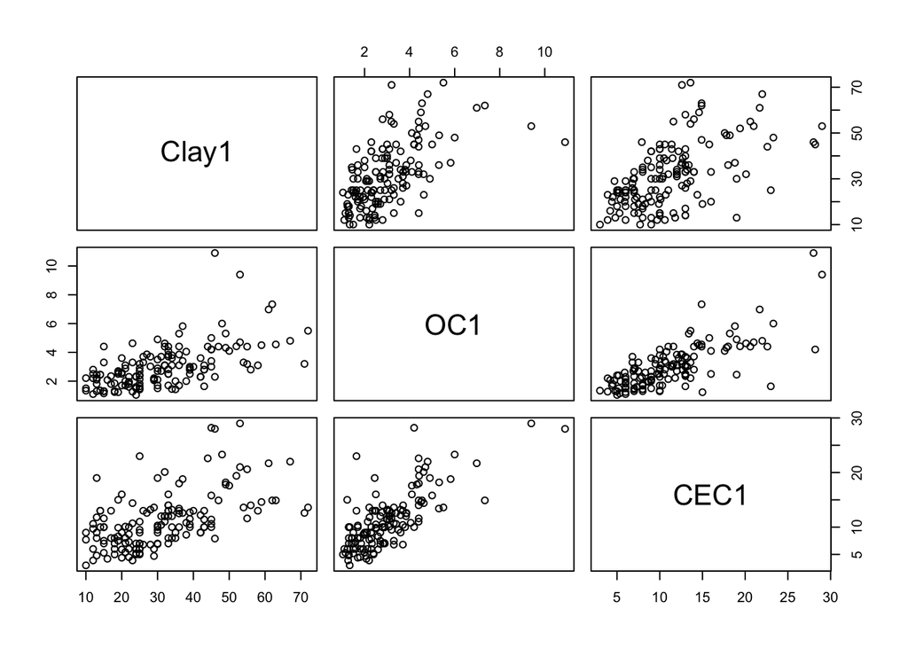

```r
pairs(~Clay1 + OC1 + CEC1, data = soil)
```

Now, let’s caluclate the covariation and correlation between the variables.

```r
topsoil <- dplyr::select(soil, CEC1, Clay1, OC1)
cov(topsoil)
```

```
##           CEC1     Clay1       OC1
## CEC1  25.94793  39.60916  5.679280
## Clay1 39.60916 194.21312 12.502137
## OC1    5.67928  12.50214  2.252044
```

```r
cor(topsoil)
```

```
##            CEC1     Clay1       OC1
## CEC1  1.0000000 0.5579624 0.7429396
## Clay1 0.5579624 1.0000000 0.5978009
## OC1   0.7429396 0.5978009 1.0000000
```

> 14. In 3-5 sentences, interpret these results for me. Check the documentation on the functions for assistance as needed.

## Pairwise partial correlations

Simple bivariate pairs show how two variables are related. These kind of relationships can be used to investigate whether there any underlying relations between the entire set.

If you find a strong simple correlation between $x$ and $y$, it could be due to the fact that they are both **actually** correlated to the underlying variable $z$. **Partial correlation** shows the correlation between two variables after correcting for all others (that you know of).

So, how do you “correct” for the other variables?

First, find the correlation between the residuals of the linear regressions between the two variables to be crrelated and all other variables.

Then, if the residuals left over after the regression are correlated, this cannot be explained by the variables considered thus far

Let’s give it a try with the soild dataset from Cameroon.

### Example: pairwise partial correlations using Cameroon soil data

In this case study, we are going to ask whether the apparent correlation between clay and CEC actually due to the fact that soils with higher clay content tend to have higher OC and this OC also contributes to CEC?

This is answered by the partial correlation between clay and CEC, in both cases correcting for OC. We can compute partial correlations directly from the definition, which is easy in this case with only three variables.

We also recompute the simple correlations, computed above but repeated here for comparison. It’s not logical (although mathematically possible) to compute the partial correlation of Clay and OC, since the “lurking” variable CEC is a result of these two, not a cause of either.

So, in this case, we only consider the correlation of CEC with OC and Clay separately

```r
cor(residuals(lm(CEC1~Clay1, data = topsoil)), residuals(lm(OC1~Clay1, data = topsoil)))
```

```
## [1] 0.6153842
```

```r
cor(residuals(lm(CEC1~OC1, data = topsoil)), residuals(lm(Clay1~OC1, data = topsoil)))
```

```
## [1] 0.2121414
```

```r
cor(topsoil$CEC1, topsoil$OC1)
```

```
## [1] 0.7429396
```

```r
cor(topsoil$CEC1, topsoil$Clay1)
```

```
## [1] 0.5579624
```

In this case, we see that CEC is only wealy positively correlated to Clay after controllng for OC ($r = 0.21$), whereas CEC is highly positively correlated to OC, even afetr controlling for Clay ($r = 0.62$), but note that our simple correlation slightly higher at $r = 0.74$! Thus, we can draw the conclusion that much of the apparent correlation between Clay and CEC is explained by the mutual positive correlation with OC.

> 15. Given this information, if you had to select a single best predictor of CEC in topsoil, which variable would you select?

### Visualizing our pairwise partial corrleations

Let’s take a look at what we are trying to communicate here. We are going to make two plots. The first is CEC vs. Clay, and the second is the residuals of CEC regressed on OC vs Clay regressed on OC.

```r
fit1 <- ggplot(topsoil, aes(x = Clay1, y = CEC1)) +
  geom_point() +
  geom_hline(yintercept=mean(topsoil$CEC1)) +
  geom_vline(xintercept=mean(topsoil$Clay1)) +
  ylab("Percent Clay") +
  xlab("CEC cmol+/(kg soil)") +
  ggtitle("Clay vs. CEC at 0-10 cm")
fit2 <- ggplot(topsoil, aes(x = residuals(lm(CEC1~OC1, data = topsoil)), y = residuals(lm(Clay1~OC1, data = topsoil)))) +
  geom_point() +
  geom_hline(yintercept=mean(residuals(lm(CEC1~OC1, data = topsoil)))) +
  geom_vline(xintercept=mean(residuals(lm(Clay1~OC1, data = topsoil)))) +
  ylab("Residuals, % Clay vs. % OC") +
  xlab("Residuals, CEC vs. OC") +
  ggtitle("Partial Corr. of Clay vs. CEC \n after correcting for OC")
```

Beacuse these are large and lengthy plots, I have assigned them as objects. I can now just call the objects and load them into a nice publication-quality graphics package.

[figure not shown]

```r
library(cowplot) # this is a supes cool package. Check it out.
plot_grid(fit1, fit2, labels = "AUTO")
```

### Simultaneous computation of partial correlations

While it isn’t too hard to do the piece-by-piece partial correlation by hand with only three variables, imagine what a pain this would turn into with 5 variables. Or 8. Luckily, R can handle this for us quite efficiently.

```r
require(ppcor)
?pcor
pcor(topsoil, method = "pearson")
```

```
## $estimate
##            CEC1     Clay1       OC1
## CEC1  1.0000000 0.2121414 0.6153842
## Clay1 0.2121414 1.0000000 0.3299294
## OC1   0.6153842 0.3299294 1.0000000
##
## $p.value
##               CEC1        Clay1          OC1
## CEC1  0.000000e+00 1.015197e-02 1.399321e-16
## Clay1 1.015197e-02 0.000000e+00 4.767205e-05
## OC1   1.399321e-16 4.767205e-05 0.000000e+00
##
## $statistic
##           CEC1    Clay1      OC1
## CEC1  0.000000 2.604990 9.368631
## Clay1 2.604990 0.000000 4.193993
## OC1   9.368631 4.193993 0.000000
##
## $n
## [1] 147
##
## $gp
## [1] 1
##
## $method
## [1] "pearson"
```

```r
#or...
pcor(topsoil, method = "kendall")
```

```
## $estimate
##            CEC1     Clay1       OC1
## CEC1  1.0000000 0.2238975 0.4261769
## Clay1 0.2238975 1.0000000 0.2987253
## OC1   0.4261769 0.2987253 1.0000000
##
## $p.value
##               CEC1        Clay1          OC1
## CEC1  0.000000e+00 6.073454e-05 2.298818e-14
## Clay1 6.073454e-05 0.000000e+00 8.791452e-08
## OC1   2.298818e-14 8.791452e-08 0.000000e+00
##
## $statistic
##           CEC1    Clay1      OC1
## CEC1  0.000000 4.009939 7.632703
## Clay1 4.009939 0.000000 5.350082
## OC1   7.632703 5.350082 0.000000
##
## $n
## [1] 147
##
## $gp
## [1] 1
##
## $method
## [1] "kendall"
```

## Multiple Regression Analysis

In multiple regression analysis, our objective is to develop the best *predictive equation* for some response variable, given several possible explanatory variables.

Acknowledgements: Much of this comes from Helsel, D. and Hirsch R. (2002) [Statistical Methods in Water Resources](https://pubs.usgs.gov/twri/twri4a3/pdf/twri4a3-new.pdf). US Geological Survey, Techniques of Water-Resources Investigations 522 p.

### The importance of variable selection

One of the major issues in multiple regression is the appropriate approach to variable selection. The **benefit** of adding additional variables to a multiple regression model is to account for or explain more of the variance of the response variable. The **cost** of adding additional variables is that the degrees of freedom decreases, making it more difficult to find significance in hypothesis tests and increasing the width of confidence intervals. A good model will explain as much of the variance of $y$ as possible with a small number of explanatory variables.

The first step is to consider only explanatory variables which ought to have some effect on the dependent variable. There must be plausible theory behind why a variable might be expected to influence the magnitude of $y$. Simply minimizing the SSE or maximizing $R^2$ are not sufficient criteria. In fact, any explanatory variable will reduce the $SSE$ and increase the $R^2$ by some small amount, even those irrelevant to the situation (or even random numbers!). The benefit of adding these unrelated variables, however, is small compared to the cost of a degree of freedom. Therefore the choice of whether to add a variable is based on a “cost-benefit analysis”, and variables enter the model only if they make a significant improvement in the model.

#### Methods for evaluating a new variable for model improvement

There are at least two types of approaches for evaluating whether a new variable sufficiently improves the model. The first approach uses partial F or t-tests, and when automated is often called a “stepwise” procedure. The second approach uses some overall measure of model quality. The latter has many advantages. Thus, we will start with the overall measure of quality.

In our current case study, CEC depends on reactive sites on clay colloids and humus. If we can establish a good predictive relation for CEC from Clay and or OC, we can use this at sites where we haven’t measured CEC.

So, what is our first step in this analysis? Visualize! (Of course!)

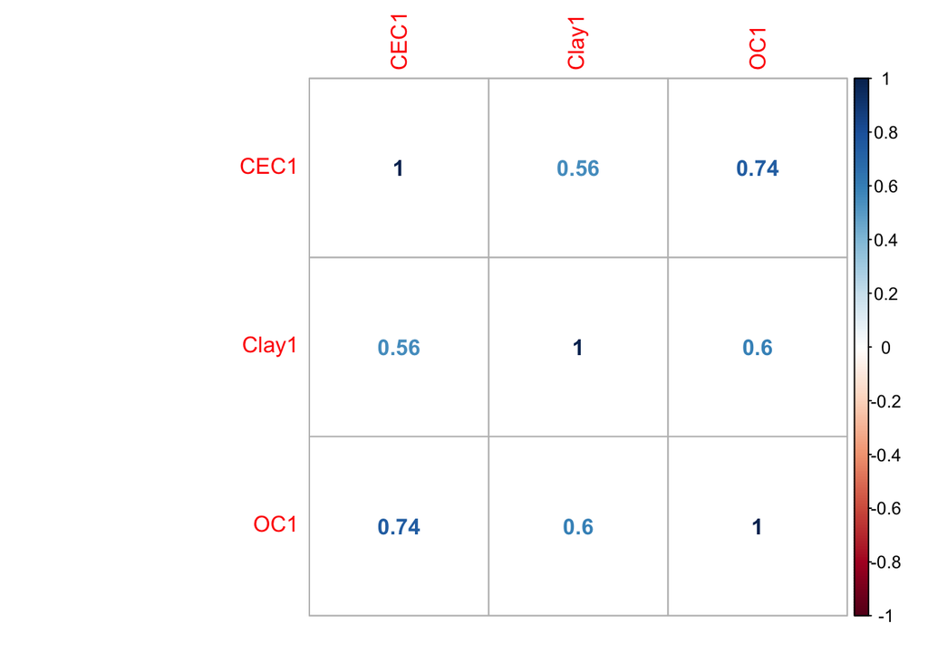

```r
require(corrplot)
mycor <- cor(topsoil)
corrplot(mycor, method = "number")
```

Next, we want to compute simple regressions and the multiple regression and compare with the null. In this case, our $H_{0}$ is that every value is predicted by the mean

```r
lm.null <- lm(CEC1 ~ 1, data = topsoil); summary(lm.null)
```

```
##
## Call:
## lm(formula = CEC1 ~ 1, data = topsoil)
##
## Residuals:
##    Min     1Q Median     3Q    Max
## -8.204 -3.704 -1.104  1.896 17.796
##
## Coefficients:
##             Estimate Std. Error t value Pr(>|t|)
## (Intercept)  11.2041     0.4201   26.67   <2e-16 ***
## ---
## Signif. codes:  0 '***' 0.001 '**' 0.01 '*' 0.05 '.' 0.1 ' ' 1
##
## Residual standard error: 5.094 on 146 degrees of freedom
```

```r
lm.cec.oc <- lm(CEC1 ~ OC1, data = topsoil); summary(lm.cec.oc)
```

```
##
## Call:
## lm(formula = CEC1 ~ OC1, data = topsoil)
##
## Residuals:
##     Min      1Q  Median      3Q     Max
## -7.2809 -2.2469 -0.2099  1.5770 15.1936
##
## Coefficients:
##             Estimate Std. Error t value Pr(>|t|)
## (Intercept)   3.6706     0.6304   5.823 3.57e-08 ***
## OC1           2.5218     0.1887  13.365  < 2e-16 ***
## ---
## Signif. codes:  0 '***' 0.001 '**' 0.01 '*' 0.05 '.' 0.1 ' ' 1
##
## Residual standard error: 3.421 on 145 degrees of freedom
## Multiple R-squared:  0.552,  Adjusted R-squared:  0.5489
## F-statistic: 178.6 on 1 and 145 DF,  p-value: < 2.2e-16
```

```r
lm.cec.clay <- lm(CEC1 ~ Clay1, data = topsoil); summary(lm.cec.clay)
```

```
##
## Call:
## lm(formula = CEC1 ~ Clay1, data = topsoil)
##
## Residuals:
##     Min      1Q  Median      3Q     Max
## -6.7065 -3.3512 -0.6446  2.2007 14.1962
##
## Coefficients:
##             Estimate Std. Error t value Pr(>|t|)
## (Intercept)  4.82623    0.86195   5.599 1.05e-07 ***
## Clay1        0.20395    0.02519   8.096 2.11e-13 ***
## ---
## Signif. codes:  0 '***' 0.001 '**' 0.01 '*' 0.05 '.' 0.1 ' ' 1
##
## Residual standard error: 4.242 on 145 degrees of freedom
## Multiple R-squared:  0.3113, Adjusted R-squared:  0.3066
## F-statistic: 65.55 on 1 and 145 DF,  p-value: 2.107e-13
```

```r
lm.cec.clay.oc <- lm(CEC1 ~ Clay1 + OC1, data = topsoil); summary(lm.cec.clay.oc)
```

```
##
## Call:
## lm(formula = CEC1 ~ Clay1 + OC1, data = topsoil)
##
## Residuals:
##     Min      1Q  Median      3Q     Max
## -7.7059 -2.0159 -0.3772  1.2887 15.1154
##
## Coefficients:
##             Estimate Std. Error t value Pr(>|t|)
## (Intercept)  2.71960    0.71790   3.788 0.000222 ***
## Clay1        0.06475    0.02485   2.605 0.010152 *
## OC1          2.16240    0.23081   9.369  < 2e-16 ***
## ---
## Signif. codes:  0 '***' 0.001 '**' 0.01 '*' 0.05 '.' 0.1 ' ' 1
##
## Residual standard error: 3.355 on 144 degrees of freedom
## Multiple R-squared:  0.5721, Adjusted R-squared:  0.5662
## F-statistic: 96.27 on 2 and 144 DF,  p-value: < 2.2e-16
```

> 15. Using tidyverse and the broom package, clean up the lm results from above. Make a summary table that has the following columns: r square; adjusted r square, sigma, statistic, p.value, df, logLik, AIC, BIC, deviance, df.residual. Each row should be each of the different linear models. Show your work.

Next, we want to investigate how much does adding clay to the predictive equation using only organic carbon change the equation? We are going to examine two different aspects of this:

1. How much more explanation is gained?
2. Does the model summary show this as a statistically-significant increase?

```r
lms <- list(null=lm.null, cec.clay = lm.cec.clay, cec.oc = lm.cec.oc, cec.clay.oc = lm.cec.clay.oc)
lms.coeffs <- lapply(lms, tidy)
```

> 16. Using your answer from 14 and looking at the lm coefficients above, answer the above two questions. 1) How much explanation is gained by adding Clay? Is this a statistically signafigant increase? Support your answers with quantitative results.

*Side Note*: Some of you really hate lists, so here is one way how you could get this out of a list.

However, in this case, it is probbably easier to cross-compare your results with a list. But here it is anyhow:

```r
lms.coeffs.notalist <- Map(cbind, lms.coeffs, model = names(lms))
lms.coeffs.notalist <- bind_rows(lms.coeffs.notalist)
lms.coeffs.notalist
```

| term | estimate | std.error | statistic | p.value | model |
| --- | --- | --- | --- | --- | --- |
| (Intercept) | 11.20408163 | 0.42013869 | 26.667579 | 5.536254e-58 | null |
| (Intercept) | 4.82623330 | 0.86195444 | 5.599174 | 1.046303e-07 | cec.clay |
| Clay1 | 0.20394686 | 0.02519046 | 8.096193 | 2.107487e-13 | cec.clay |
| (Intercept) | 3.67060960 | 0.63035188 | 5.823112 | 3.574732e-08 | cec.oc |
| OC1 | 2.52183368 | 0.18868514 | 13.365301 | 4.652740e-27 | cec.oc |
| (Intercept) | 2.71960230 | 0.71789537 | 3.788299 | 2.222135e-04 | cec.clay.oc |
| Clay1 | 0.06474623 | 0.02485470 | 2.604990 | 1.015197e-02 | cec.clay.oc |
| OC1 | 2.16239739 | 0.23081252 | 9.368631 | 1.399321e-16 | cec.clay.oc |

# Comparing Regression Models

Often, when we create multiple regression models, what we really want to know is, which of these models is best?

Multiple regression can be a dangerous analysis. It’s really easy to add more variables as you think of them, or just because the data are handy. It is likely that some of the predictors will be significant. This could be because there is a relationship, but it might just be due to chance. Your $R^2$ value will incraese when you add more variables - encouraging you to continue! Similarly, you will probably find that you can add higher-order polynomials to bend and twist that fitted line as you like. Your $R^2$ will probably increase, but are you fitting real patterns or just connecting the dots?

In statistics we often want a **parsimonious* model. Even though we may end up with a really good fit when we make a model complex, an overspecified model (one that’s too complex) is more likely to reduce the precision of coefficient estimates and predicted values.

**Parsimony**: Explain as much of the variance in the datasets as possible with as few predictive factors as possible.

## Model Selection and Diagnostic Statistics

### The problem with R squared

1. Every time you add a predictor to a model, the R-squared increases, even if due to chance alone. It never decreases. Consequently, a model with more terms may appear to have a better fit simply because it has more terms.
2. If a model has too many predictors and higher order polynomials, it begins to model the random noise in the data. This condition is known as **overfitting** the model and it produces misleadingly high R-squared values and a lessened ability to make predictions.

So, there are multiple ways to assess our models that can help us value **parsimony** and get away from $R^2$.

### Adjusted R Squared

The adjusted R-squared compares the explanatory power of regression models that contain different numbers of predictors. The adjusted R-squared is a modified version of R-squared that has been adjusted for the number of predictors in the model. The adjusted R-squared increases only if the new term improves the model more than would be expected by chance. It decreases when a predictor improves the model by less than expected by chance. The adjusted R-squared can be negative, but it’s usually not. It is always lower than the R-squared in multiple regression.

Use the adjusted R-square to compare models with different numbers of predictors

The Adjusted $R^2$ is found by:

$$R^2_{adj} = 1 - \Big[\frac{n-1}{n-p}\cdot(1-R^2)\Big]$$

where $n$ is the number of observations

and $p$ is the number of coefficients

> 17. What is the adjusted R square of the 4 different lms?

### AIC

*Akaike’s Information Criterion* (AIC) is a more general measure of model performance. AIC rewards goodness of fit while penalizing for number of parameters.

$$AIC = -2log[L(\hat{\theta}|data)]+2k$$

where $L(\hat{\theta}|data)$ is the likelihood of the estimated model parameter $\hat{\theta}$

and $k$ is the number of parametrs in the model

Note thattThe log-likelihood functions are parameterized in terms of the means, but the specific form of the individual contributions depends on the model (e.g., binomial, poisson, etc.)

It is a “badness of fit” measure-The lower the value the better the model fits the data. Some general guidelines for using the AIC are:

(Taken from this Rblog [post](https://www.r-bloggers.com/how-do-i-interpret-the-aic/) - go check it out!)

1. A lower AIC indicates a more parsimonious model, relative to a model fit with a higher AIC.
2. It is a relative measure of model parsimony, so it only has meaning if we compare the AIC for alternate hypotheses (= different models of the data).
3. We can compare non-nested models. For instance, we could compare a linear to a non-linear model.
4. The comparisons are only valid for models that are fit to the same response data (i.e., values of y).
5. Model selection conducted with the AIC will choose the same model as leave-one-out cross validation (where we leave out one data point and fit the model, then evaluate its fit to that point) for large sample sizes.
6. You shouldn’t compare too many models with the AIC. You will run into the same problems with multiple model comparison as you would with p-values, in that you might by chance find a model with thel lowest AIC, that isn’t truly the most appropriate model. (We are going to read a lot about this in our next homework assignment)
7. When using the AIC you might end up with multiple models that perform similarly to each other. So you have similar evidence weights for different alternate hypotheses. You are going to have to make an informed decision - you can’t just rely on this statistic for model selection every time!
8. You should correct for small sample sizes if you use the AIC with small sample sizes, by using the AICc statistic.

> 18. Define the AICc statistic. What is the function for calculating the AICc statistic in R?

### BIC

The *Bayseian Information Crietrion* (BIC) is similar to AIC, but with a different penalty for the number of parameters. BIC is an estimate of a function of the posterior probability of a model being true, under a certain Bayesian setup, so that a lower BIC means that a model is considered to be more likely to be the true model.

the BIC is found by:

$$BIC=2log_e\lambda-(p_1-p_2)log_en$$
Where $\lambda$ is the likelihood ratio $L(data|M_0)/L(data|M_1)$ for two models ($M_0$ and $M_1$) with different number of parameters $p_1$ and $p_2$

When using the BIC, the best model is the one with the lowest BIC. Well, what do I choose, the BIC or the AIC? The AIC has been shown to be more stable in simulations than BIC given a range of asymptotic conditions. Whereas, the BIC penalizes model complexity more heavily, so tends to choose more *parsimonious* models.

Functionally, if using AIC and BIC to choose the correct model, you should be ok with either. The only way they should disagree is when AIC chooses a larger model than BIC. the best rule of thumb is to look at both and think about your asusmptions. One way to look at it is that AIC is better in situations when a false negative finding would be considered more misleading than a false positive, and BIC is better in situations where a false positive is as misleading as, or more misleading than, a false negative.

> 19. Find the AIC and the BIC of each of the 4 lm models. Make a side-by-side bar plot visualizing the AIC and BIC for each of the 4 models (so, x-axis = model, y-axis = test statistic value, color = test statistic type).

> 20. Which of the 4 lms is best? Why?

## Comparing Models with Hypothesis Tests (F-Tests/ANOVA)

So now we have some tools for how to select the best model. But, how do we know if the different models are actually, (statistically signifigantly) different?

The traditional way to evaluate nested models (where one is a more complex version of the other) is to compare them in an ANOVA table. We want to make sure we always compare the more complex model first. Then we compute the proportional reduction in the residual sum of squares (RSS)

```r
a <- anova(lm.cec.clay.oc, lm.cec.clay)
a
```

|  | Res.Df | RSS | Df | Sum of Sq | F | Pr(>F) |
| --- | --- | --- | --- | --- | --- | --- |
| 1 | 144 | 1620.969 | NA | NA | NA | NA |
| 2 | 145 | 2608.986 | -1 | -988.017 | 87.77125 | 1.399321e-16 |

```r
diff(a$RSS)/a$RSS
```

```
## [1] 0.6095226 0.3786977
```

```r
b <- anova(lm.cec.clay.oc, lm.cec.oc)
b
```

|  | Res.Df | RSS | Df | Sum of Sq | F | Pr(>F) |
| --- | --- | --- | --- | --- | --- | --- |
| 1 | 144 | 1620.969 | NA | NA | NA | NA |
| 2 | 145 | 1697.357 | -1 | -76.38782 | 6.78597 | 0.01015197 |

```r
diff(b$RSS)/(b$RSS)
```

```
## [1] 0.04712479 0.04500399
```

Next, we must always visualize our results. Always!

> 21. Plot the regression diagnostic plots, and the predicted (fitted) versus observed values for all 4 lms. For the diagnostic plots, use par(mfrow) and plot 4 diagnostic plots in a 2 x 2 grid. Include residuals vs fitted, normal q-q, scale-location, and residuals versus leverage.

## Summary of Model Selection Criteria

Rules for selection of linear regression models are summarized in the 5 steps below:

1. Should $y$ be transformed? To decide whether to transform the $y$ variable, plot residuals versus predicted values for the untransformed data. Compare this to a residuals plot for the best transformed model, looking for three things: -constant variance across the range of $\hat{y}$ -normality of residuals a linear pattern, not curvature.

The statistics $R^2$, SSE, AIC, etc. are not appropriate for comparison of models having different units of y.

2. Should $x$ (or several $x's$) be transformed? Transformation of an $x$ variable should be made using partial plots. Check for the same three patterns of constant variance, normality and linearity. Considerable help can be obtained from statistics such as $R^2$ (maximize it), or $SSE$ minimize it. Many transformations can be rapidly checked with such statistics, but a residuals plot should always be inspected prior to making any final decision.
3. Which of several models, each with the same $y$ and with the same number of explanatory variables, is preferable? Use of $R^2$, $SSE$ is appropriate here, but back it up with a residuals plot.
4. Which of several nested models, each with the same $y$, is preferable? Use the partial F test between any pair of nested models to find which is best. One may also select the model based on minimum AIC or BIC.
5. Which of several models is preferable when each uses the same $y$ variable but are not necessarily nested? AIC or BIC can be used here, or check the predictions errors.

> 21. Given the results from the ANOVA and the proportional difference in the residual sum of the squares, as well as the visualizations, what is the probability that the difference in the models is due to chance? (Or, put another wasy, can we reject our null hypothesis that the extra information from the clay content does not really improve the model)? Explain your reasoning.

# Stepwise Multiple Regression

Stepwise procedures are automated model selection methods in which the computer algorithm determines which model is preferred. There are three versions, usually called forwards, backwards, and stepwise. These procedures use a sequence of partial F or t-tests to evaluate the significance of a variable. The three versions do not always agree on a “best” model, especially when multi-collinearity is present. They also do not evaluate all possible models, and so cannot guarantee that the “best” model is even tested. They were developed prior to modern computer technology, taking shortcuts to avoid running all possible regression equations for comparison. Such shortcuts are no longer necessary.

Forward selection starts with only an intercept and adds variables to the equation one at a time. Once in, each variable stays in the model. All variables not in the model are evaluated with partial F or t statistics in comparison to the existing model. The variable with the highest significant partial F or t statistic is included, and the process repeats until either all available variables are included or no new variables are significant. One drawback to this method is that the resulting model may have coefficients which are not significantly different from zero; they must only be significant when they enter. A second drawback is that two variables which each individually provide little explanation of y may never enter, but together the variables would explain a great deal. Forward selection is unable to capitalize on this situation.

Backward elimination starts with all explanatory variables in the model and eliminates the one with the lowest partial-F statistic (lowest $|t|$). It stops when all remaining variables are significant. The backwards algorithm does ensure that the final model has only significant variables, but does not ensure a “best” model because it also cannot consider the combined significance of groups of variables.

Stepwise regression combines the ideas of forward and backward. It alternates between adding and removing variables, checking significance of individual variables within and outside the model. Variables significant when entering the model will be eliminated if later they test as insignificant. Even so, stepwise does not test all possible regression models.

To perform stepwise multiple regression in R, you use the `step()` function. You want to first specify model object (e.g., `lm()`), and then define *scope* - how variables in the full model should be added or subtracted.

In the simplest case we don’t specify scope, and `step()` will try to eliminate all variables one at a time until no more can be eliminated without increasing **AIC**.

So, let’s give it a try. Can we predict subsoil clay from all three topsoil parameters?

Let stepwise pick the best from a full model:

```r
require(tidyverse)
lms <- step(lm(Clay2 ~ Clay1 + CEC1 + OC1, data = soil))
```

```
## Start:  AIC=461.91
## Clay2 ~ Clay1 + CEC1 + OC1
##
##         Df Sum of Sq     RSS    AIC
## <none>                3223.5 461.91
## - OC1    1      81.3  3304.8 463.56
## - CEC1   1     179.1  3402.6 467.86
## - Clay1  1   21077.8 24301.3 756.85
```

> 22. Given the above results, should we eliminate any of the variables?

Now, let’s start to build some predictive models.

```r
lms <- step(lm(Clay5 ~ Clay1 + CEC1 + OC1 + Clay2 + CEC2 + OC2, data = soil))
```

```
## Start:  AIC=420.7
## Clay5 ~ Clay1 + CEC1 + OC1 + Clay2 + CEC2 + OC2
##
##         Df Sum of Sq    RSS    AIC
## - CEC1   1      0.73 2338.8 418.75
## - OC1    1      8.66 2346.8 419.24
## - OC2    1     12.16 2350.3 419.46
## - Clay1  1     27.25 2365.4 420.40
## <none>               2338.1 420.70
## - CEC2   1     48.46 2386.6 421.72
## - Clay2  1   1763.89 4102.0 501.33
##
## Step:  AIC=418.75
## Clay5 ~ Clay1 + OC1 + Clay2 + CEC2 + OC2
##
##         Df Sum of Sq    RSS    AIC
## - OC1    1     10.88 2349.7 417.43
## - OC2    1     11.51 2350.4 417.47
## - Clay1  1     31.15 2370.0 418.69
## <none>               2338.8 418.75
## - CEC2   1     75.89 2414.7 421.44
## - Clay2  1   1966.50 4305.3 506.45
##
## Step:  AIC=417.43
## Clay5 ~ Clay1 + Clay2 + CEC2 + OC2
##
##         Df Sum of Sq    RSS    AIC
## - OC2    1      5.49 2355.2 415.77
## - Clay1  1     21.30 2371.0 416.75
## <none>               2349.7 417.43
## - CEC2   1     66.90 2416.6 419.55
## - Clay2  1   2294.24 4644.0 515.58
##
## Step:  AIC=415.77
## Clay5 ~ Clay1 + Clay2 + CEC2
##
##         Df Sum of Sq    RSS    AIC
## <none>               2355.2 415.77
## - Clay1  1     36.45 2391.7 416.03
## - CEC2   1     62.28 2417.5 417.61
## - Clay2  1   2310.92 4666.1 514.27
```

> 23. Under what case is **AIC** most improved? Explain your reasoning. (Note - there is not one correct answer here).

## Parallel Regression: Combining Discrete and Continuous Predictors

What if I have both *discrete factors* and *continuous variables*?

Can I predict the clay content of the 30-50 cm layer from the agro-ecological zone and the measured clay in the topsoil?

```r
soil$zone <- as.factor(soil$zone)
```

# Parallel Regression: Combining Discrete and Continuous Predictors

Often there are factors which influence the dependent variable which are not appropriately expressed as a continuous variable. Examples of such grouped or qualitative variables include location (stations, aquifers, positions in a cross section), or time (day & night; winter & summer; before & after some event such as a flood, a drought, operation of a sewage treatment plant or reservoir).

These factors are perfectly valid explanatory variables in a multiple regression context. They can be incorporated by the use of binary or “dummy” variables, essentially blending regression and analysis of variance into an analysis of covariance.

For example, do we think that the zone in which the soil was sampled is an important explanatory variable in the models we are building?

We can look into this using parallell regression.

$$Z_i = \Bigg\langle\ \begin{array}{ll} 0_{zone_1}\\ 1_{zone_2} \end{array}$$

We model:

$Y = \beta_0 + \beta_1X + \beta_2Z +\epsilon$

When slope coefficient $\beta_2$ is signifigant, this model is preffered over simple linear regression

Note! This equation says $Y$ and $X$ are affected by $Z$

Let’s try this on our soil data:

Step 1: Predict Clay on zone

```r
lm5z <- lm(Clay5 ~ zone, data = soil); summary (lm5z)
```

```
##
## Call:
## lm(formula = Clay5 ~ zone, data = soil)
##
## Residuals:
##     Min      1Q  Median      3Q     Max
## -32.950  -5.396   0.159   3.159  24.050
##
## Coefficients:
##             Estimate Std. Error t value Pr(>|t|)
## (Intercept)   55.000      3.209  17.138  < 2e-16 ***
## zone2          0.950      3.515   0.270  0.78737
## zone3        -11.159      3.407  -3.275  0.00132 **
## zone4        -23.667      3.548  -6.671 5.18e-10 ***
## ---
## Signif. codes:  0 '***' 0.001 '**' 0.01 '*' 0.05 '.' 0.1 ' ' 1
##
## Residual standard error: 9.077 on 143 degrees of freedom
## Multiple R-squared:  0.5126, Adjusted R-squared:  0.5023
## F-statistic: 50.12 on 3 and 143 DF,  p-value: < 2.2e-16
```

Step 2: Predict Clay5 on Clay1

```r
lm51 <- lm(Clay5 ~ Clay1, data = soil); summary(lm51)
```

```
##
## Call:
## lm(formula = Clay5 ~ Clay1, data = soil)
##
## Residuals:
##      Min       1Q   Median       3Q      Max
## -20.6258  -3.1907   0.0055   3.3875  14.1500
##
## Coefficients:
##             Estimate Std. Error t value Pr(>|t|)
## (Intercept) 18.75856    1.15561   16.23   <2e-16 ***
## Clay1        0.82891    0.03377   24.54   <2e-16 ***
## ---
## Signif. codes:  0 '***' 0.001 '**' 0.01 '*' 0.05 '.' 0.1 ' ' 1
##
## Residual standard error: 5.687 on 145 degrees of freedom
## Multiple R-squared:  0.806,  Adjusted R-squared:  0.8047
## F-statistic: 602.4 on 1 and 145 DF,  p-value: < 2.2e-16
```

Step 3: Predict Clay5 on Clay1 **AND** Zone

```r
lm5z1 <- lm(Clay5 ~ zone + Clay1, data = soil); summary(lm5z1)
```

```
##
## Call:
## lm(formula = Clay5 ~ zone + Clay1, data = soil)
##
## Residuals:
##      Min       1Q   Median       3Q      Max
## -24.0863  -2.9937   0.1505   3.1385  13.8878
##
## Coefficients:
##             Estimate Std. Error t value Pr(>|t|)
## (Intercept) 19.32443    2.90540   6.651 5.83e-10 ***
## zone2        5.69448    2.10604   2.704  0.00769 **
## zone3        2.25099    2.18312   1.031  0.30425
## zone4       -0.65940    2.53650  -0.260  0.79527
## Clay1        0.73558    0.04525  16.256  < 2e-16 ***
## ---
## Signif. codes:  0 '***' 0.001 '**' 0.01 '*' 0.05 '.' 0.1 ' ' 1
##
## Residual standard error: 5.385 on 142 degrees of freedom
## Multiple R-squared:  0.8296, Adjusted R-squared:  0.8248
## F-statistic: 172.9 on 4 and 142 DF,  p-value: < 2.2e-16
```

> 24. How much of the variation in subsoil clay is explained by the zone? By the topsoil clay? by both together? Is the combined model better than individual models? How much so?

> 25. In the parallel regression model (topsoil clay and zone as predictors), what are the differences in the means between zones?

> 26. What is the slope of the linear regression, after accounting for the zones? How does this compare with the slope of the linear regression not considering zones?

> 27. Are all predictors in the combined model (topsoil clay and zone as predictors) significant? (*Hint*: look at the probability of the t-tests.)

## Assumptions of the paralell regression

Take a look at the form of our model: `Clay5 ~ zone + Clay1`

This is an *additive* model. This means it has 1 regression line for the *continuous* predictor, and it has displaced vertically according to the mean value of the *discrete* predictor. This means we are making some assumptions here.

One is that that the only effect of the *discrete* predictor is to adjust the mean.

Another is that thee relation between predictor and explanatory variables is the same for all classess of the *discrete* factor. We know that different processes occur in different soil zones. So, maybe we should be a bit cuatious witht his assumption.

## Parallel Regression: Diagnostics

First, let’s examine the residuals. We want to look for any points that are poorly predicted, and then, of course, look for any patterns in our residuals and check to see if they are normally distributed.

Here’s a cool new way to look at residuals:

```r
stem(residuals(lm5z1))
```

```
##
##   The decimal point is at the |
##
##   -24 | 1
##   -22 |
##   -20 |
##   -18 |
##   -16 |
##   -14 |
##   -12 |
##   -10 | 540
##    -8 | 77104
##    -6 | 10099662
##    -4 | 888539854322
##    -2 | 8655321009876110
##    -0 | 9866654322110987666555321
##     0 | 00122334445679023444466688889
##     2 | 0334488900122333345568
##     4 | 0336800058
##     6 | 35792244
##     8 | 5
##    10 | 11188
##    12 | 49
```

Next, let’s display the records for the poorly modeled points

```r
res.low <- which(residuals(lm5z1) < -12)
res.high <- which(residuals(lm5z1) > 9)
soil[res.low,]
```

| X1 | e | n | elev | zone | wrb1 | LC | Clay1 | Clay2 | Clay5 | CEC1 | CEC2 | CEC5 | OC1 | OC2 | OC5 |
| --- | --- | --- | --- | --- | --- | --- | --- | --- | --- | --- | --- | --- | --- | --- | --- |
| 145 | 695098 | 328237 | 547 | 2 | 3 | OCA | 30 | 18 | 23 | 7 | 6 | 7 | 1.5 | 0.8 | 0.8 |

```r
soil[res.high,]
```

| X1 | e | n | elev | zone | wrb1 | LC | Clay1 | Clay2 | Clay5 | CEC1 | CEC2 | CEC5 | OC1 | OC2 | OC5 |
| --- | --- | --- | --- | --- | --- | --- | --- | --- | --- | --- | --- | --- | --- | --- | --- |
| 9 | 681230 | 311053 | 600 | 2 | 3 | FV | 46 | 56 | 70 | 7.9 | 5.7 | 4.5 | 2.30 | 1.36 | 0.9 |
| 27 | 679242 | 338073 | 360 | 3 | 1 | FV | 24 | 35 | 51 | 5.0 | 5.4 | 13.1 | 1.04 | 0.52 | 0.5 |
| 38 | 671039 | 336819 | 130 | 4 | 1 | OCA | 13 | 23 | 40 | 4.8 | 3.4 | 3.2 | 1.30 | 0.34 | 0.2 |
| 42 | 667325 | 334883 | 243 | 4 | 1 | FV | 23 | 38 | 48 | 3.9 | 4.2 | 4.9 | 1.27 | 0.58 | 0.5 |
| 119 | 666452 | 337405 | 134 | 4 | 1 | BF | 21 | 40 | 48 | 5.4 | 2.6 | 7.5 | 2.00 | 0.60 | 0.4 |
| 128 | 699567 | 328185 | 630 | 2 | 3 | MCA | 17 | 40 | 47 | 8.0 | 8.0 | 8.0 | 1.80 | 0.90 | 0.8 |
| 137 | 698928 | 328368 | 640 | 2 | 3 | FV | 42 | 61 | 66 | 9.0 | 9.0 | 8.0 | 2.30 | 1.30 | 1.0 |
| 139 | 695014 | 328757 | 560 | 2 | 3 | FV | 42 | 60 | 66 | 9.0 | 8.0 | 8.0 | 2.30 | 1.20 | 1.0 |

And finally, let’s compare with predicted values

```r
predict(lm5z1)[res.low]
```

```
##      145
## 47.08628
```

```r
predict(lm5z1)[res.high]
```

```
##        9       27       38       42      119      128      137      139
## 58.85554 39.22931 28.22756 35.58334 34.11219 37.52375 55.91322 55.91322
```

Next step, always, visualize!

> 28. Plot these parellel regression lines

# Correlated predictr variables (Multi-colinearity)

It is very important that practitioners of MLR understand the causes and consequences of multi- collinearity, and can diagnose its presence. Multi-collinearity is the condition where at least one explanatory variable is closely related to one or more other explanatory variables. Most importantly, we want to avoid having correlated preditcor variables, because it makes it difficult to interpret important effects. It also causes bias in effect size/oarameter estimates, and it can lead to overfitting (poor predictive power).

Multi-colinearity has undesirable consequences for the regression equation, including:

1. Equations acceptable interms of overall F-tests may have slope coefficients with magnitudes which are unrealistically large, and whose partial F or t-tests are found to be insignificant.
2. Coefficients may be unrealistic in sign (a negative slope for a regression of streamflow vs. precipitation, (etc). Usually this occurs when two variables describing approximately the same thing are counter-balancing each other in the equation, having opposite signs.
3. Slope coefficients are unstable. A small change in one or a few data values could cause a large change in the coefficients.
4. Automatic procedures such as stepwise, forwards and backwards methods produce different models judged to be “best”.

Concern over multi-collinearity should be strongest when the purpose is to make inferences about coefficients. Concern can be somewhat less when only predictions are of interest, provided that these predictions are for cases within the observed range of the $x$ data.

An excellent diagnostic for measuring multi-collinearity is the variance inflation factor (VIF) presented by Marquardt (1970).

For variable $j$ the $VIF$ is

$$VIF_{j}=\frac{1}{(1−R_{j}^2)}$$

where $R_{j}^2$ is the $R^2$ from a regression of the $jth$ explanatory variable on all of the other explanatory variables -the equation used for adjustment of $x_{j}$ in partial plots.

The ideal is $VIF_{j} ≅ 1$, corresponding to $R_{j}^2 ≅ 0$.

Bad news bears when $VIF_{j} > 10$ ($R_{j}^2 > 0.9$).

A useful interpretation of VIF is that multi-collinearity “inflates” the width of the confidence interval for the $jth$ regression coefficient by the amount $VIF_{j}$ compared to what it would be with a perfectly independent set of explanatory variables.

or

how much of the variance of an estimated regression coeeificent is increased because of collinearity?

## Solutions for Multi-collinearity

There are four options for working with a regression equation having one or more high VIF values.

1. **Center the data.** A simple solution which works in some specific cases is to center the data. Multi-collinearity can arise when some of the explanatory variables are functions of other explanatory variables, such as for a polynomial regression of $y$ against $x$ and $x2$. When $x$ is always of one sign, there may be a strong relationship between it and its square. Centering redefines the explanatory variables by subtracting a constant from the original variable, and then recomputing the derived variables. This constant should be one which produces about as many positive values as negative values, such as the mean or median. When all of the derived explanatory variables are recomputed as functions (squares, products, etc.) of these centered variables, their multi-collinearity will be reduced.

Centering is a mathematical solution to a mathematical problem. It will not reduce multi- collinearity between two variables which are not mathematically derived one from another. It is particularly useful when the original explanatory variable has been defined with respect to some arbitrary datum (time, distance, temperature) and is easily fixed by resetting the datum to roughly the middle of the data. In some cases the multi-collinearity can be so severe that the numerical methods used by the statistical software fail to perform the necessary matrix computations correctly. Such numerical problems occur frequently when doing trend surface analysis (e.g., fitting a high order polynomial of distances north of the equator and west of Greenwich) or trend analysis (e.g., values are a polynomial of years).

2. **Eliminate variables.** In some cases prior judgment suggests the use of several different variables which describe related but not identical attributes. Examples of this might be: air temperature and dew point temperature, the maximum 1-hour rainfall, and the maximum 2- hour rainfall, river basin population and area in urban land use, basin area forested and basin area above 6,000 feet elevation, and so on. Such variables may be strongly related as shown by their VIFs, and one of them must eliminated on judgmental grounds, or on the basis of comparisons of models fit with one eliminated versus the other eliminated, in order to lower the VIF.
3. **Collect additional data.** Multi-collinearity can sometimes be solved with only a few additional but strategically selected observations. Suppose some attributes of river basins are being studied, and small basins tend to be heavily forested while large basins tend to be less heavily forested. Discerning the relative importance of size versus the importance of forest cover will prove to be difficult. Strong multi-collinearity will result from including both variables in the regression equation. To solve this and allow the effects of each variable to be judged separately, collect additional samples from a few small less forested basins and a few large but heavily-forested basins. This produces a much more reliable model. Similar problems arise in ground-water quality studies, where rural wells are shallow and urban wells are deeper. Depth and population density may show strong multi-collinearity, requiring some shallow urban and deeper rural wells to be sampled.
4. **Perform ridge regression.** Ridge regression was proposed by Hoerl and Kenard (1970). Montgomery and Peck (1982) give a good brief discussion of it. It is based on the idea that the variance of the slope estimates can be greatly reduced by introducing some bias into them. It is a controversial but useful method in multiple regression.

## Variance Inflation Factor

```r
library(car)
vif(lm(Clay5 ~ Clay1 + CEC1 + OC1 + Clay2 + CEC2 + OC2, data=soil))
```

```
##     Clay1      CEC1       OC1     Clay2      CEC2       OC2
## 12.839076  4.771181  4.094407 10.388219  3.553141  3.034883
```

> 29. Recompute the VIF, take each one out separately. Show the results.

```
##    Clay1     CEC1      OC1     CEC2      OC2
## 2.592702 4.220827 4.091648 3.321821 3.021352
```

```
##    Clay2     CEC1      OC1     CEC2      OC2
## 2.097780 4.503400 4.027701 3.525554 2.903654
```

> 30. What is the best model to predict Clay 5? Why?